# Risk Factor Analysis

## Outcome Variable

**Outcome Variable:** wasted

## Predictor Variables

**Intervention Variable:** meducyrs

**Adjustment Set:**

unadjusted

## Stratifying Variables

The analysis was stratified on these variable(s):

- agecat
- studyid
- country

## Data Summary

| agecat | studyid | country | meducyrs | wasted | n_cell | n | outcome_variable |
| --- | --- | --- | --- | --- | --- | --- | --- |
| Birth | ki0047075b-MAL-ED | BANGLADESH | High | 0 | 56 | 175 | wasted |
| Birth | ki0047075b-MAL-ED | BANGLADESH | High | 1 | 8 | 175 | wasted |
| Birth | ki0047075b-MAL-ED | BANGLADESH | Low | 0 | 51 | 175 | wasted |
| Birth | ki0047075b-MAL-ED | BANGLADESH | Low | 1 | 9 | 175 | wasted |
| Birth | ki0047075b-MAL-ED | BANGLADESH | Medium | 0 | 39 | 175 | wasted |
| Birth | ki0047075b-MAL-ED | BANGLADESH | Medium | 1 | 12 | 175 | wasted |
| Birth | ki0047075b-MAL-ED | BRAZIL | High | 0 | 18 | 62 | wasted |
| Birth | ki0047075b-MAL-ED | BRAZIL | High | 1 | 0 | 62 | wasted |
| Birth | ki0047075b-MAL-ED | BRAZIL | Low | 0 | 16 | 62 | wasted |
| Birth | ki0047075b-MAL-ED | BRAZIL | Low | 1 | 1 | 62 | wasted |
| Birth | ki0047075b-MAL-ED | BRAZIL | Medium | 0 | 26 | 62 | wasted |
| Birth | ki0047075b-MAL-ED | BRAZIL | Medium | 1 | 1 | 62 | wasted |
| Birth | ki0047075b-MAL-ED | INDIA | High | 0 | 8 | 38 | wasted |
| Birth | ki0047075b-MAL-ED | INDIA | High | 1 | 0 | 38 | wasted |
| Birth | ki0047075b-MAL-ED | INDIA | Low | 0 | 15 | 38 | wasted |
| Birth | ki0047075b-MAL-ED | INDIA | Low | 1 | 3 | 38 | wasted |
| Birth | ki0047075b-MAL-ED | INDIA | Medium | 0 | 11 | 38 | wasted |
| Birth | ki0047075b-MAL-ED | INDIA | Medium | 1 | 1 | 38 | wasted |
| Birth | ki0047075b-MAL-ED | NEPAL | High | 0 | 4 | 24 | wasted |
| Birth | ki0047075b-MAL-ED | NEPAL | High | 1 | 1 | 24 | wasted |
| Birth | ki0047075b-MAL-ED | NEPAL | Low | 0 | 12 | 24 | wasted |
| Birth | ki0047075b-MAL-ED | NEPAL | Low | 1 | 0 | 24 | wasted |
| Birth | ki0047075b-MAL-ED | NEPAL | Medium | 0 | 6 | 24 | wasted |
| Birth | ki0047075b-MAL-ED | NEPAL | Medium | 1 | 1 | 24 | wasted |
| Birth | ki0047075b-MAL-ED | PERU | High | 0 | 63 | 228 | wasted |
| Birth | ki0047075b-MAL-ED | PERU | High | 1 | 2 | 228 | wasted |
| Birth | ki0047075b-MAL-ED | PERU | Low | 0 | 83 | 228 | wasted |
| Birth | ki0047075b-MAL-ED | PERU | Low | 1 | 0 | 228 | wasted |
| Birth | ki0047075b-MAL-ED | PERU | Medium | 0 | 77 | 228 | wasted |
| Birth | ki0047075b-MAL-ED | PERU | Medium | 1 | 3 | 228 | wasted |

[output cut: 396 more lines]

The following strata were considered:

- agecat: 24 months, studyid: ki0047075b-MAL-ED, country: BANGLADESH
- agecat: 24 months, studyid: ki0047075b-MAL-ED, country: BRAZIL
- agecat: 24 months, studyid: ki0047075b-MAL-ED, country: INDIA
- agecat: 24 months, studyid: ki0047075b-MAL-ED, country: NEPAL
- agecat: 24 months, studyid: ki0047075b-MAL-ED, country: PERU
- agecat: 24 months, studyid: ki0047075b-MAL-ED, country: SOUTH AFRICA
- agecat: 24 months, studyid: ki0047075b-MAL-ED, country: TANZANIA, UNITED REPUBLIC OF
- agecat: 24 months, studyid: ki1000108-CMC-V-BCS-2002, country: INDIA
- agecat: 24 months, studyid: ki1000108-IRC, country: INDIA
- agecat: 24 months, studyid: ki1000109-EE, country: PAKISTAN
- agecat: 24 months, studyid: ki1017093-NIH-Birth, country: BANGLADESH
- agecat: 24 months, studyid: ki1017093b-PROVIDE, country: BANGLADESH
- agecat: 24 months, studyid: ki1017093c-NIH-Crypto, country: BANGLADESH
- agecat: 24 months, studyid: ki1066203-TanzaniaChild2, country: TANZANIA, UNITED REPUBLIC OF
- agecat: 24 months, studyid: ki1113344-GMS-Nepal, country: NEPAL
- agecat: 24 months, studyid: ki1119695-PROBIT, country: BELARUS
- agecat: 24 months, studyid: ki1126311-ZVITAMBO, country: ZIMBABWE
- agecat: 24 months, studyid: ki1135781-COHORTS, country: GUATEMALA
- agecat: 24 months, studyid: ki1135781-COHORTS, country: INDIA
- agecat: 24 months, studyid: ki1135781-COHORTS, country: PHILIPPINES
- agecat: 24 months, studyid: ki1148112-LCNI-5, country: MALAWI
- agecat: 24 months, studyid: kiGH5241-JiVitA-3, country: BANGLADESH
- agecat: 24 months, studyid: kiGH5241-JiVitA-4, country: BANGLADESH
- agecat: 6 months, studyid: ki0047075b-MAL-ED, country: BANGLADESH
- agecat: 6 months, studyid: ki0047075b-MAL-ED, country: BRAZIL
- agecat: 6 months, studyid: ki0047075b-MAL-ED, country: INDIA
- agecat: 6 months, studyid: ki0047075b-MAL-ED, country: NEPAL
- agecat: 6 months, studyid: ki0047075b-MAL-ED, country: PERU
- agecat: 6 months, studyid: ki0047075b-MAL-ED, country: SOUTH AFRICA
- agecat: 6 months, studyid: ki0047075b-MAL-ED, country: TANZANIA, UNITED REPUBLIC OF
- agecat: 6 months, studyid: ki1000108-CMC-V-BCS-2002, country: INDIA
- agecat: 6 months, studyid: ki1000108-IRC, country: INDIA
- agecat: 6 months, studyid: ki1000109-EE, country: PAKISTAN
- agecat: 6 months, studyid: ki1000304b-SAS-CompFeed, country: INDIA
- agecat: 6 months, studyid: ki1000304b-SAS-FoodSuppl, country: INDIA
- agecat: 6 months, studyid: ki1017093-NIH-Birth, country: BANGLADESH
- agecat: 6 months, studyid: ki1017093b-PROVIDE, country: BANGLADESH
- agecat: 6 months, studyid: ki1017093c-NIH-Crypto, country: BANGLADESH
- agecat: 6 months, studyid: ki1066203-TanzaniaChild2, country: TANZANIA, UNITED REPUBLIC OF
- agecat: 6 months, studyid: ki1112895-Guatemala BSC, country: GUATEMALA
- agecat: 6 months, studyid: ki1113344-GMS-Nepal, country: NEPAL
- agecat: 6 months, studyid: ki1119695-PROBIT, country: BELARUS
- agecat: 6 months, studyid: ki1126311-ZVITAMBO, country: ZIMBABWE
- agecat: 6 months, studyid: ki1135781-COHORTS, country: GUATEMALA
- agecat: 6 months, studyid: ki1135781-COHORTS, country: INDIA
- agecat: 6 months, studyid: ki1135781-COHORTS, country: PHILIPPINES
- agecat: 6 months, studyid: ki1148112-LCNI-5, country: MALAWI
- agecat: 6 months, studyid: kiGH5241-JiVitA-3, country: BANGLADESH
- agecat: 6 months, studyid: kiGH5241-JiVitA-4, country: BANGLADESH
- agecat: Birth, studyid: ki0047075b-MAL-ED, country: BANGLADESH
- agecat: Birth, studyid: ki0047075b-MAL-ED, country: BRAZIL
- agecat: Birth, studyid: ki0047075b-MAL-ED, country: INDIA
- agecat: Birth, studyid: ki0047075b-MAL-ED, country: NEPAL
- agecat: Birth, studyid: ki0047075b-MAL-ED, country: PERU
- agecat: Birth, studyid: ki0047075b-MAL-ED, country: SOUTH AFRICA
- agecat: Birth, studyid: ki0047075b-MAL-ED, country: TANZANIA, UNITED REPUBLIC OF
- agecat: Birth, studyid: ki1000108-CMC-V-BCS-2002, country: INDIA
- agecat: Birth, studyid: ki1000108-IRC, country: INDIA
- agecat: Birth, studyid: ki1000109-EE, country: PAKISTAN
- agecat: Birth, studyid: ki1000304b-SAS-CompFeed, country: INDIA
- agecat: Birth, studyid: ki1017093-NIH-Birth, country: BANGLADESH
- agecat: Birth, studyid: ki1017093b-PROVIDE, country: BANGLADESH
- agecat: Birth, studyid: ki1017093c-NIH-Crypto, country: BANGLADESH
- agecat: Birth, studyid: ki1113344-GMS-Nepal, country: NEPAL
- agecat: Birth, studyid: ki1119695-PROBIT, country: BELARUS
- agecat: Birth, studyid: ki1126311-ZVITAMBO, country: ZIMBABWE
- agecat: Birth, studyid: ki1135781-COHORTS, country: GUATEMALA
- agecat: Birth, studyid: ki1135781-COHORTS, country: INDIA
- agecat: Birth, studyid: ki1135781-COHORTS, country: PHILIPPINES
- agecat: Birth, studyid: kiGH5241-JiVitA-3, country: BANGLADESH
- agecat: Birth, studyid: kiGH5241-JiVitA-4, country: BANGLADESH

### Dropped Strata

Some strata were dropped due to rare outcomes:

- agecat: Birth, studyid: ki0047075b-MAL-ED, country: BRAZIL
- agecat: Birth, studyid: ki0047075b-MAL-ED, country: INDIA
- agecat: Birth, studyid: ki0047075b-MAL-ED, country: NEPAL
- agecat: Birth, studyid: ki0047075b-MAL-ED, country: PERU
- agecat: Birth, studyid: ki0047075b-MAL-ED, country: SOUTH AFRICA
- agecat: Birth, studyid: ki0047075b-MAL-ED, country: TANZANIA, UNITED REPUBLIC OF
- agecat: Birth, studyid: ki1000108-CMC-V-BCS-2002, country: INDIA
- agecat: Birth, studyid: ki1000109-EE, country: PAKISTAN
- agecat: 6 months, studyid: ki0047075b-MAL-ED, country: BANGLADESH
- agecat: 6 months, studyid: ki0047075b-MAL-ED, country: BRAZIL
- agecat: 6 months, studyid: ki0047075b-MAL-ED, country: NEPAL
- agecat: 6 months, studyid: ki0047075b-MAL-ED, country: PERU
- agecat: 6 months, studyid: ki0047075b-MAL-ED, country: SOUTH AFRICA
- agecat: 6 months, studyid: ki0047075b-MAL-ED, country: TANZANIA, UNITED REPUBLIC OF
- agecat: 6 months, studyid: ki1000109-EE, country: PAKISTAN
- agecat: 6 months, studyid: ki1000304b-SAS-FoodSuppl, country: INDIA
- agecat: 6 months, studyid: ki1017093c-NIH-Crypto, country: BANGLADESH
- agecat: 6 months, studyid: ki1066203-TanzaniaChild2, country: TANZANIA, UNITED REPUBLIC OF
- agecat: 6 months, studyid: ki1112895-Guatemala BSC, country: GUATEMALA
- agecat: 6 months, studyid: ki1113344-GMS-Nepal, country: NEPAL
- agecat: 6 months, studyid: ki1148112-LCNI-5, country: MALAWI
- agecat: 24 months, studyid: ki0047075b-MAL-ED, country: BANGLADESH
- agecat: 24 months, studyid: ki0047075b-MAL-ED, country: BRAZIL
- agecat: 24 months, studyid: ki0047075b-MAL-ED, country: INDIA
- agecat: 24 months, studyid: ki0047075b-MAL-ED, country: NEPAL
- agecat: 24 months, studyid: ki0047075b-MAL-ED, country: PERU
- agecat: 24 months, studyid: ki0047075b-MAL-ED, country: SOUTH AFRICA
- agecat: 24 months, studyid: ki0047075b-MAL-ED, country: TANZANIA, UNITED REPUBLIC OF
- agecat: 24 months, studyid: ki1000109-EE, country: PAKISTAN
- agecat: 24 months, studyid: ki1066203-TanzaniaChild2, country: TANZANIA, UNITED REPUBLIC OF
- agecat: 24 months, studyid: ki1148112-LCNI-5, country: MALAWI

## Methods Detail

We’re interested in the causal parameters $E[Y_a]$ for all values of $a \in \mathcal{A}$. These parameters represent the mean outcome if, possibly contrary to fact, we intervened to set all units to have $A=a$. Under the randomization and positivity assumptions, these are identified by the statistical parameters $\psi_a=E_W[E_{Y|A,W}(Y|A=a,W)]$. In addition, we’re interested in the mean of $Y$, $E[Y]$ under no intervention (the observed mean). We will estimate these parameters by using SuperLearner to fit the relevant likelihood factors – $E_{Y|A,W}(Y|A=a,W)$ and $p(A=a|W)$, and then updating our likelihood fit using a joint TMLE.

For unadjusted analyses ($W=\{\}$), initial likelihoods were estimated using Lrnr_glm to estimate the simple $E(Y|A)$ and Lrnr_mean to estimate $p(A)$. For adjusted analyses, a small library containing Lrnr_glmnet, Lrnr_xgboost, and Lrnr_mean was used.

Having estimated these parameters, we will then use the delta method to estimate relative risks and attributable risks relative to a prespecified baseline level of $A$.

# Results Detail

## Results Plots

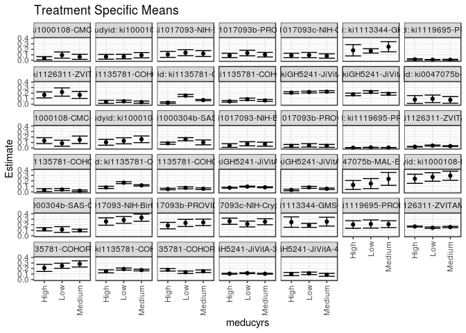

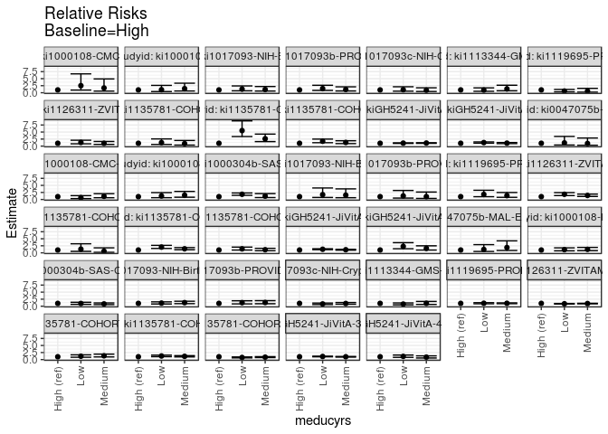

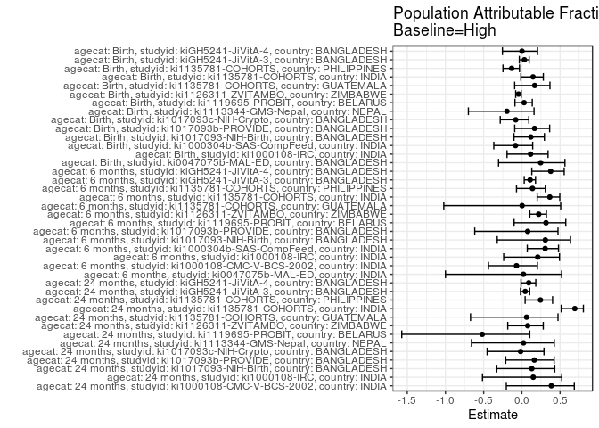

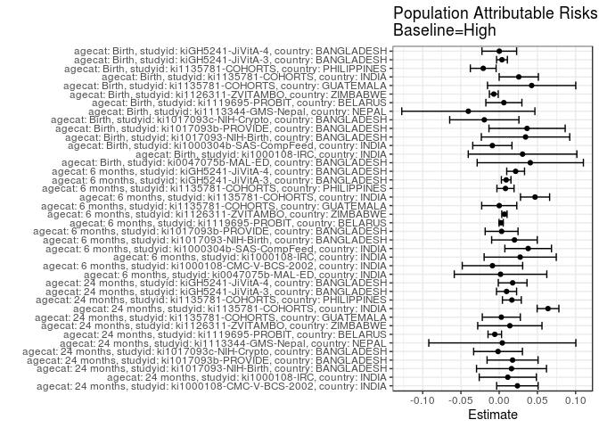

## Results Table

### Parameter: TSM

| agecat | studyid | country | intervention_level | baseline_level | estimate | ci_lower | ci_upper |
| --- | --- | --- | --- | --- | --- | --- | --- |
| Birth | ki0047075b-MAL-ED | BANGLADESH | High | NA | 0.1250000 | 0.0437429 | 0.2062571 |
| Birth | ki0047075b-MAL-ED | BANGLADESH | Low | NA | 0.1500000 | 0.0593909 | 0.2406091 |
| Birth | ki0047075b-MAL-ED | BANGLADESH | Medium | NA | 0.2352941 | 0.1185432 | 0.3520450 |
| Birth | ki1000108-IRC | INDIA | High | NA | 0.2376238 | 0.1544951 | 0.3207525 |
| Birth | ki1000108-IRC | INDIA | Low | NA | 0.2698413 | 0.1922238 | 0.3474588 |
| Birth | ki1000108-IRC | INDIA | Medium | NA | 0.2931034 | 0.2101487 | 0.3760582 |
| Birth | ki1000304b-SAS-CompFeed | INDIA | High | NA | 0.1158798 | 0.0868080 | 0.1449517 |
| Birth | ki1000304b-SAS-CompFeed | INDIA | Low | NA | 0.1120000 | 0.0591325 | 0.1648675 |
| Birth | ki1000304b-SAS-CompFeed | INDIA | Medium | NA | 0.0945946 | 0.0713435 | 0.1178457 |
| Birth | ki1017093-NIH-Birth | BANGLADESH | High | NA | 0.2576687 | 0.1904698 | 0.3248676 |
| Birth | ki1017093-NIH-Birth | BANGLADESH | Low | NA | 0.2857143 | 0.2245612 | 0.3468674 |
| Birth | ki1017093-NIH-Birth | BANGLADESH | Medium | NA | 0.3267327 | 0.2619975 | 0.3914679 |
| Birth | ki1017093b-PROVIDE | BANGLADESH | High | NA | 0.1834320 | 0.1250274 | 0.2418365 |
| Birth | ki1017093b-PROVIDE | BANGLADESH | Low | NA | 0.2317073 | 0.1670723 | 0.2963423 |
| Birth | ki1017093b-PROVIDE | BANGLADESH | Medium | NA | 0.2412060 | 0.1817103 | 0.3007018 |
| Birth | ki1017093c-NIH-Crypto | BANGLADESH | High | NA | 0.2627119 | 0.2065220 | 0.3189017 |
| Birth | ki1017093c-NIH-Crypto | BANGLADESH | Low | NA | 0.2123894 | 0.1590284 | 0.2657503 |
| Birth | ki1017093c-NIH-Crypto | BANGLADESH | Medium | NA | 0.2530612 | 0.1985824 | 0.3075400 |
| Birth | ki1113344-GMS-Nepal | NEPAL | High | NA | 0.2469136 | 0.1529325 | 0.3408947 |
| Birth | ki1113344-GMS-Nepal | NEPAL | Low | NA | 0.1869369 | 0.1506453 | 0.2232286 |
| Birth | ki1113344-GMS-Nepal | NEPAL | Medium | NA | 0.2543860 | 0.1743769 | 0.3343951 |
| Birth | ki1119695-PROBIT | BELARUS | High | NA | 0.2025881 | 0.1336920 | 0.2714843 |
| Birth | ki1119695-PROBIT | BELARUS | Low | NA | 0.2117718 | 0.1376755 | 0.2858682 |
| Birth | ki1119695-PROBIT | BELARUS | Medium | NA | 0.2085779 | 0.1466020 | 0.2705537 |
| Birth | ki1126311-ZVITAMBO | ZIMBABWE | High | NA | 0.1665004 | 0.1577825 | 0.1752182 |
| Birth | ki1126311-ZVITAMBO | ZIMBABWE | Low | NA | 0.1446051 | 0.1313312 | 0.1578790 |
| Birth | ki1126311-ZVITAMBO | ZIMBABWE | Medium | NA | 0.1566719 | 0.1440477 | 0.1692961 |
| Birth | ki1135781-COHORTS | GUATEMALA | High | NA | 0.2101911 | 0.1464151 | 0.2739670 |
| Birth | ki1135781-COHORTS | GUATEMALA | Low | NA | 0.2500000 | 0.2042111 | 0.2957889 |
| Birth | ki1135781-COHORTS | GUATEMALA | Medium | NA | 0.2834008 | 0.2271629 | 0.3396387 |

[output cut: 90 more lines]

### Parameter: E(Y)

| agecat | studyid | country | intervention_level | baseline_level | estimate | ci_lower | ci_upper |
| --- | --- | --- | --- | --- | --- | --- | --- |
| Birth | ki0047075b-MAL-ED | BANGLADESH | NA | NA | 0.1657143 | 0.1104670 | 0.2209616 |
| Birth | ki1000108-IRC | INDIA | NA | NA | 0.2682216 | 0.2212677 | 0.3151755 |
| Birth | ki1000304b-SAS-CompFeed | INDIA | NA | NA | 0.1069810 | 0.0760961 | 0.1378659 |
| Birth | ki1017093-NIH-Birth | BANGLADESH | NA | NA | 0.2921739 | 0.2549711 | 0.3293768 |
| Birth | ki1017093b-PROVIDE | BANGLADESH | NA | NA | 0.2199248 | 0.1846953 | 0.2551543 |
| Birth | ki1017093c-NIH-Crypto | BANGLADESH | NA | NA | 0.2432815 | 0.2116319 | 0.2749310 |
| Birth | ki1113344-GMS-Nepal | NEPAL | NA | NA | 0.2065728 | 0.1751584 | 0.2379871 |
| Birth | ki1119695-PROBIT | BELARUS | NA | NA | 0.2087491 | 0.1435025 | 0.2739957 |
| Birth | ki1126311-ZVITAMBO | ZIMBABWE | NA | NA | 0.1594945 | 0.1531752 | 0.1658137 |
| Birth | ki1135781-COHORTS | GUATEMALA | NA | NA | 0.2526738 | 0.2215120 | 0.2838356 |
| Birth | ki1135781-COHORTS | INDIA | NA | NA | 0.1750359 | 0.1643722 | 0.1856996 |
| Birth | ki1135781-COHORTS | PHILIPPINES | NA | NA | 0.1555709 | 0.1423748 | 0.1687670 |
| Birth | kiGH5241-JiVitA-3 | BANGLADESH | NA | NA | 0.1096842 | 0.1045577 | 0.1148108 |
| Birth | kiGH5241-JiVitA-4 | BANGLADESH | NA | NA | 0.0995399 | 0.0841638 | 0.1149160 |
| 6 months | ki0047075b-MAL-ED | INDIA | NA | NA | 0.0865385 | 0.0482372 | 0.1248397 |
| 6 months | ki1000108-CMC-V-BCS-2002 | INDIA | NA | NA | 0.1250000 | 0.0911644 | 0.1588356 |
| 6 months | ki1000108-IRC | INDIA | NA | NA | 0.1323529 | 0.0994307 | 0.1652752 |
| 6 months | ki1000304b-SAS-CompFeed | INDIA | NA | NA | 0.1244378 | 0.0992652 | 0.1496104 |
| 6 months | ki1017093-NIH-Birth | BANGLADESH | NA | NA | 0.0651769 | 0.0442802 | 0.0860736 |
| 6 months | ki1017093b-PROVIDE | BANGLADESH | NA | NA | 0.0414594 | 0.0255348 | 0.0573839 |
| 6 months | ki1119695-PROBIT | BELARUS | NA | NA | 0.0082498 | 0.0066007 | 0.0098989 |
| 6 months | ki1126311-ZVITAMBO | ZIMBABWE | NA | NA | 0.0312058 | 0.0275075 | 0.0349041 |
| 6 months | ki1135781-COHORTS | GUATEMALA | NA | NA | 0.0325289 | 0.0212599 | 0.0437978 |
| 6 months | ki1135781-COHORTS | INDIA | NA | NA | 0.1283521 | 0.1194359 | 0.1372684 |
| 6 months | ki1135781-COHORTS | PHILIPPINES | NA | NA | 0.0594974 | 0.0505830 | 0.0684118 |
| 6 months | kiGH5241-JiVitA-3 | BANGLADESH | NA | NA | 0.0846305 | 0.0798233 | 0.0894378 |
| 6 months | kiGH5241-JiVitA-4 | BANGLADESH | NA | NA | 0.0570539 | 0.0482012 | 0.0659066 |
| 24 months | ki1000108-CMC-V-BCS-2002 | INDIA | NA | NA | 0.0618280 | 0.0373207 | 0.0863352 |
| 24 months | ki1000108-IRC | INDIA | NA | NA | 0.0757946 | 0.0501131 | 0.1014762 |
| 24 months | ki1017093-NIH-Birth | BANGLADESH | NA | NA | 0.1238318 | 0.0925894 | 0.1550741 |
| 24 months | ki1017093b-PROVIDE | BANGLADESH | NA | NA | 0.1070812 | 0.0818727 | 0.1322897 |
| 24 months | ki1017093c-NIH-Crypto | BANGLADESH | NA | NA | 0.0875486 | 0.0630907 | 0.1120065 |
| 24 months | ki1113344-GMS-Nepal | NEPAL | NA | NA | 0.1859504 | 0.1512529 | 0.2206479 |
| 24 months | ki1119695-PROBIT | BELARUS | NA | NA | 0.0110775 | 0.0050478 | 0.0171072 |
| 24 months | ki1126311-ZVITAMBO | ZIMBABWE | NA | NA | 0.1824480 | 0.1460286 | 0.2188675 |
| 24 months | ki1135781-COHORTS | GUATEMALA | NA | NA | 0.0458801 | 0.0333262 | 0.0584341 |
| 24 months | ki1135781-COHORTS | INDIA | NA | NA | 0.0921747 | 0.0833896 | 0.1009599 |
| 24 months | ki1135781-COHORTS | PHILIPPINES | NA | NA | 0.0681911 | 0.0582056 | 0.0781766 |
| 24 months | kiGH5241-JiVitA-3 | BANGLADESH | NA | NA | 0.2181099 | 0.2082292 | 0.2279905 |
| 24 months | kiGH5241-JiVitA-4 | BANGLADESH | NA | NA | 0.1947502 | 0.1814990 | 0.2080014 |

### Parameter: RR

| agecat | studyid | country | intervention_level | baseline_level | estimate | ci_lower | ci_upper |
| --- | --- | --- | --- | --- | --- | --- | --- |
| Birth | ki0047075b-MAL-ED | BANGLADESH | High | High | 1.0000000 | 1.0000000 | 1.0000000 |
| Birth | ki0047075b-MAL-ED | BANGLADESH | Low | High | 1.2000000 | 0.4940740 | 2.9145433 |
| Birth | ki0047075b-MAL-ED | BANGLADESH | Medium | High | 1.8823529 | 0.8308823 | 4.2644459 |
| Birth | ki1000108-IRC | INDIA | High | High | 1.0000000 | 1.0000000 | 1.0000000 |
| Birth | ki1000108-IRC | INDIA | Low | High | 1.1355820 | 0.7219803 | 1.7861242 |
| Birth | ki1000108-IRC | INDIA | Medium | High | 1.2334770 | 0.7865128 | 1.9344446 |
| Birth | ki1000304b-SAS-CompFeed | INDIA | High | High | 1.0000000 | 1.0000000 | 1.0000000 |
| Birth | ki1000304b-SAS-CompFeed | INDIA | Low | High | 0.9665185 | 0.6634127 | 1.4081100 |
| Birth | ki1000304b-SAS-CompFeed | INDIA | Medium | High | 0.8163164 | 0.5675297 | 1.1741631 |
| Birth | ki1017093-NIH-Birth | BANGLADESH | High | High | 1.0000000 | 1.0000000 | 1.0000000 |
| Birth | ki1017093-NIH-Birth | BANGLADESH | Low | High | 1.1088435 | 0.7913120 | 1.5537918 |
| Birth | ki1017093-NIH-Birth | BANGLADESH | Medium | High | 1.2680339 | 0.9138832 | 1.7594262 |
| Birth | ki1017093b-PROVIDE | BANGLADESH | High | High | 1.0000000 | 1.0000000 | 1.0000000 |
| Birth | ki1017093b-PROVIDE | BANGLADESH | Low | High | 1.2631786 | 0.8272244 | 1.9288844 |
| Birth | ki1017093b-PROVIDE | BANGLADESH | Medium | High | 1.3149619 | 0.8790122 | 1.9671227 |
| Birth | ki1017093c-NIH-Crypto | BANGLADESH | High | High | 1.0000000 | 1.0000000 | 1.0000000 |
| Birth | ki1017093c-NIH-Crypto | BANGLADESH | Low | High | 0.8084499 | 0.5812416 | 1.1244742 |
| Birth | ki1017093c-NIH-Crypto | BANGLADESH | Medium | High | 0.9632653 | 0.7111356 | 1.3047865 |
| Birth | ki1113344-GMS-Nepal | NEPAL | High | High | 1.0000000 | 1.0000000 | 1.0000000 |
| Birth | ki1113344-GMS-Nepal | NEPAL | Low | High | 0.7570946 | 0.4938408 | 1.1606822 |
| Birth | ki1113344-GMS-Nepal | NEPAL | Medium | High | 1.0302632 | 0.6287995 | 1.6880456 |
| Birth | ki1119695-PROBIT | BELARUS | High | High | 1.0000000 | 1.0000000 | 1.0000000 |
| Birth | ki1119695-PROBIT | BELARUS | Low | High | 1.0453319 | 0.8729808 | 1.2517101 |
| Birth | ki1119695-PROBIT | BELARUS | Medium | High | 1.0295661 | 0.8946167 | 1.1848721 |
| Birth | ki1126311-ZVITAMBO | ZIMBABWE | High | High | 1.0000000 | 1.0000000 | 1.0000000 |
| Birth | ki1126311-ZVITAMBO | ZIMBABWE | Low | High | 0.8684973 | 0.7813999 | 0.9653030 |
| Birth | ki1126311-ZVITAMBO | ZIMBABWE | Medium | High | 0.9409704 | 0.8547566 | 1.0358800 |
| Birth | ki1135781-COHORTS | GUATEMALA | High | High | 1.0000000 | 1.0000000 | 1.0000000 |
| Birth | ki1135781-COHORTS | GUATEMALA | Low | High | 1.1893939 | 0.8344607 | 1.6952961 |
| Birth | ki1135781-COHORTS | GUATEMALA | Medium | High | 1.3483008 | 0.9382836 | 1.9374900 |

[output cut: 90 more lines]

### Parameter: PAR

| agecat | studyid | country | intervention_level | baseline_level | estimate | ci_lower | ci_upper |
| --- | --- | --- | --- | --- | --- | --- | --- |
| Birth | ki0047075b-MAL-ED | BANGLADESH | High | NA | 0.0407143 | -0.0287520 | 0.1101806 |
| Birth | ki1000108-IRC | INDIA | High | NA | 0.0305978 | -0.0404330 | 0.1016286 |
| Birth | ki1000304b-SAS-CompFeed | INDIA | High | NA | -0.0088989 | -0.0345544 | 0.0167567 |
| Birth | ki1017093-NIH-Birth | BANGLADESH | High | NA | 0.0345052 | -0.0232836 | 0.0922940 |
| Birth | ki1017093b-PROVIDE | BANGLADESH | High | NA | 0.0364929 | -0.0133570 | 0.0863428 |
| Birth | ki1017093c-NIH-Crypto | BANGLADESH | High | NA | -0.0194304 | -0.0647200 | 0.0258592 |
| Birth | ki1113344-GMS-Nepal | NEPAL | High | NA | -0.0403408 | -0.1274046 | 0.0467229 |
| Birth | ki1119695-PROBIT | BELARUS | High | NA | 0.0061610 | -0.0174170 | 0.0297390 |
| Birth | ki1126311-ZVITAMBO | ZIMBABWE | High | NA | -0.0070059 | -0.0127727 | -0.0012391 |
| Birth | ki1135781-COHORTS | GUATEMALA | High | NA | 0.0424827 | -0.0152321 | 0.1001976 |
| Birth | ki1135781-COHORTS | INDIA | High | NA | 0.0256456 | -0.0000029 | 0.0512942 |
| Birth | ki1135781-COHORTS | PHILIPPINES | High | NA | -0.0208476 | -0.0376976 | -0.0039975 |
| Birth | kiGH5241-JiVitA-3 | BANGLADESH | High | NA | 0.0036640 | -0.0034000 | 0.0107280 |
| Birth | kiGH5241-JiVitA-4 | BANGLADESH | High | NA | 0.0001611 | -0.0225189 | 0.0228410 |
| 6 months | ki0047075b-MAL-ED | INDIA | High | NA | 0.0017927 | -0.0587275 | 0.0623129 |
| 6 months | ki1000108-CMC-V-BCS-2002 | INDIA | High | NA | -0.0087580 | -0.0482800 | 0.0307641 |
| 6 months | ki1000108-IRC | INDIA | High | NA | 0.0275142 | -0.0196749 | 0.0747033 |
| 6 months | ki1000304b-SAS-CompFeed | INDIA | High | NA | 0.0379326 | 0.0074343 | 0.0684309 |
| 6 months | ki1017093-NIH-Birth | BANGLADESH | High | NA | 0.0200156 | -0.0098052 | 0.0498364 |
| 6 months | ki1017093b-PROVIDE | BANGLADESH | High | NA | 0.0031819 | -0.0183012 | 0.0246649 |
| 6 months | ki1119695-PROBIT | BELARUS | High | NA | 0.0026043 | -0.0001361 | 0.0053447 |
| 6 months | ki1126311-ZVITAMBO | ZIMBABWE | High | NA | 0.0068792 | 0.0034140 | 0.0103444 |
| 6 months | ki1135781-COHORTS | GUATEMALA | High | NA | 0.0000964 | -0.0228389 | 0.0230318 |
| 6 months | ki1135781-COHORTS | INDIA | High | NA | 0.0469410 | 0.0278863 | 0.0659958 |
| 6 months | ki1135781-COHORTS | PHILIPPINES | High | NA | 0.0082659 | -0.0029341 | 0.0194659 |
| 6 months | kiGH5241-JiVitA-3 | BANGLADESH | High | NA | 0.0091524 | 0.0029050 | 0.0153999 |
| 6 months | kiGH5241-JiVitA-4 | BANGLADESH | High | NA | 0.0215269 | 0.0098953 | 0.0331584 |
| 24 months | ki1000108-CMC-V-BCS-2002 | INDIA | High | NA | 0.0238533 | -0.0032516 | 0.0509582 |
| 24 months | ki1000108-IRC | INDIA | High | NA | 0.0112785 | -0.0261027 | 0.0486597 |
| 24 months | ki1017093-NIH-Birth | BANGLADESH | High | NA | 0.0161395 | -0.0296130 | 0.0618920 |
| 24 months | ki1017093b-PROVIDE | BANGLADESH | High | NA | 0.0175289 | -0.0158274 | 0.0508852 |
| 24 months | ki1017093c-NIH-Crypto | BANGLADESH | High | NA | -0.0014566 | -0.0333596 | 0.0304464 |
| 24 months | ki1113344-GMS-Nepal | NEPAL | High | NA | 0.0041322 | -0.0920409 | 0.1003054 |
| 24 months | ki1119695-PROBIT | BELARUS | High | NA | -0.0057420 | -0.0145877 | 0.0031036 |
| 24 months | ki1126311-ZVITAMBO | ZIMBABWE | High | NA | 0.0139698 | -0.0280594 | 0.0559989 |
| 24 months | ki1135781-COHORTS | GUATEMALA | High | NA | 0.0028179 | -0.0220618 | 0.0276977 |
| 24 months | ki1135781-COHORTS | INDIA | High | NA | 0.0638886 | 0.0496687 | 0.0781084 |
| 24 months | ki1135781-COHORTS | PHILIPPINES | High | NA | 0.0165994 | 0.0042481 | 0.0289508 |
| 24 months | kiGH5241-JiVitA-3 | BANGLADESH | High | NA | 0.0096621 | -0.0034629 | 0.0227871 |
| 24 months | kiGH5241-JiVitA-4 | BANGLADESH | High | NA | 0.0176175 | -0.0011423 | 0.0363774 |

### Parameter: PAF

| agecat | studyid | country | intervention_level | baseline_level | estimate | ci_lower | ci_upper |
| --- | --- | --- | --- | --- | --- | --- | --- |
| Birth | ki0047075b-MAL-ED | BANGLADESH | High | NA | 0.2456897 | -0.3051245 | 0.5640385 |
| Birth | ki1000108-IRC | INDIA | High | NA | 0.1140766 | -0.1942263 | 0.3427877 |
| Birth | ki1000304b-SAS-CompFeed | INDIA | High | NA | -0.0831818 | -0.3673012 | 0.1418988 |
| Birth | ki1017093-NIH-Birth | BANGLADESH | High | NA | 0.1180982 | -0.1034312 | 0.2951524 |
| Birth | ki1017093b-PROVIDE | BANGLADESH | High | NA | 0.1659333 | -0.0934401 | 0.3637812 |
| Birth | ki1017093c-NIH-Crypto | BANGLADESH | High | NA | -0.0798680 | -0.2829337 | 0.0910561 |
| Birth | ki1113344-GMS-Nepal | NEPAL | High | NA | -0.1952862 | -0.7000593 | 0.1596122 |
| Birth | ki1119695-PROBIT | BELARUS | High | NA | 0.0295137 | -0.0904701 | 0.1362958 |
| Birth | ki1126311-ZVITAMBO | ZIMBABWE | High | NA | -0.0439257 | -0.0806896 | -0.0084124 |
| Birth | ki1135781-COHORTS | GUATEMALA | High | NA | 0.1681326 | -0.0941799 | 0.3675599 |
| Birth | ki1135781-COHORTS | INDIA | High | NA | 0.1465164 | -0.0131418 | 0.2810145 |
| Birth | ki1135781-COHORTS | PHILIPPINES | High | NA | -0.1340068 | -0.2472762 | -0.0310237 |
| Birth | kiGH5241-JiVitA-3 | BANGLADESH | High | NA | 0.0334049 | -0.0332073 | 0.0957225 |
| Birth | kiGH5241-JiVitA-4 | BANGLADESH | High | NA | 0.0016180 | -0.2543761 | 0.2053687 |
| 6 months | ki0047075b-MAL-ED | INDIA | High | NA | 0.0207156 | -1.0000169 | 0.5205051 |
| 6 months | ki1000108-CMC-V-BCS-2002 | INDIA | High | NA | -0.0700637 | -0.4373815 | 0.2033873 |
| 6 months | ki1000108-IRC | INDIA | High | NA | 0.2078853 | -0.2379515 | 0.4931581 |
| 6 months | ki1000304b-SAS-CompFeed | INDIA | High | NA | 0.3048318 | 0.0708995 | 0.4798637 |
| 6 months | ki1017093-NIH-Birth | BANGLADESH | High | NA | 0.3070968 | -0.3224587 | 0.6369528 |
| 6 months | ki1017093b-PROVIDE | BANGLADESH | High | NA | 0.0767464 | -0.6169746 | 0.4728444 |
| 6 months | ki1119695-PROBIT | BELARUS | High | NA | 0.3156826 | -0.1016696 | 0.5749267 |
| 6 months | ki1126311-ZVITAMBO | ZIMBABWE | High | NA | 0.2204449 | 0.1045090 | 0.3213710 |
| 6 months | ki1135781-COHORTS | GUATEMALA | High | NA | 0.0029643 | -1.0222350 | 0.5084250 |
| 6 months | ki1135781-COHORTS | INDIA | High | NA | 0.3657205 | 0.2006958 | 0.4966742 |
| 6 months | ki1135781-COHORTS | PHILIPPINES | High | NA | 0.1389285 | -0.0701982 | 0.3071899 |
| 6 months | kiGH5241-JiVitA-3 | BANGLADESH | High | NA | 0.1081458 | 0.0311709 | 0.1790050 |
| 6 months | kiGH5241-JiVitA-4 | BANGLADESH | High | NA | 0.3773071 | 0.1300543 | 0.5542867 |
| 24 months | ki1000108-CMC-V-BCS-2002 | INDIA | High | NA | 0.3858008 | -0.2035002 | 0.6865471 |
| 24 months | ki1000108-IRC | INDIA | High | NA | 0.1488033 | -0.5154091 | 0.5218877 |
| 24 months | ki1017093-NIH-Birth | BANGLADESH | High | NA | 0.1303338 | -0.3283374 | 0.4306271 |
| 24 months | ki1017093b-PROVIDE | BANGLADESH | High | NA | 0.1636976 | -0.2109775 | 0.4224487 |
| 24 months | ki1017093c-NIH-Crypto | BANGLADESH | High | NA | -0.0166376 | -0.4548708 | 0.2895919 |
| 24 months | ki1113344-GMS-Nepal | NEPAL | High | NA | 0.0222222 | -0.6594230 | 0.4238664 |
| 24 months | ki1119695-PROBIT | BELARUS | High | NA | -0.5183486 | -1.5722715 | 0.1037562 |
| 24 months | ki1126311-ZVITAMBO | ZIMBABWE | High | NA | 0.0765685 | -0.1846907 | 0.2802124 |
| 24 months | ki1135781-COHORTS | GUATEMALA | High | NA | 0.0614198 | -0.6721728 | 0.4731808 |
| 24 months | ki1135781-COHORTS | INDIA | High | NA | 0.6931243 | 0.5151209 | 0.8057811 |
| 24 months | ki1135781-COHORTS | PHILIPPINES | High | NA | 0.2434253 | 0.0427656 | 0.4020219 |
| 24 months | kiGH5241-JiVitA-3 | BANGLADESH | High | NA | 0.0442991 | -0.0177708 | 0.1025836 |
| 24 months | kiGH5241-JiVitA-4 | BANGLADESH | High | NA | 0.0904621 | -0.0115449 | 0.1821824 |